# Project notebook

Mihai Falcusan

2023-03-06

# This project is a quick showcase of 3 data analysis and visualization tasks:

1. Visualizing the results of a psychology research project
2. Replicating an interesting plot
3. Analyzing and communicating findings from the RIJKS Museum data set

## Project 1: Visualizing the results of a psychology research project

Goal: visualize the most interesting responses

#### Importing and analyzing data

Importing file after a quick clean-up of duplicate values / grammatical erros in Open Refine

```
##                              text response count
## 1 Dort ist kein Aldi, sondern %%.     lidl    28
## 2 Dort ist kein Aldi, sondern %%.     rewe     6
## 3 Dort ist kein Aldi, sondern %%.     lidl     3
## 4 Dort ist kein Aldi, sondern %%.    edeka     2
## 5 Dort ist kein Aldi, sondern %%.    norma     2
## 6 Dort ist kein Aldi, sondern %%.     cafe     1
```

#### Ideea: Plot the strongest common associations

### What are the most often encountered associations?

```
##           text response count
## 933     Silber     gold    41
## 1377   Frieden    krieg    41
## 882       Obst   gemüse    40
## 2363      Dorf    stadt    39
## 1171       Tee   kaffee    36
## 552  Badewanne   dusche    34
## 1031   Wohnung     haus    34
## 1163   Mädchen    junge    34
## 784       Mann     frau    33
## 1121     Katze     hund    33
## 1489      Aldi     lidl    31
## 1850      Esel    pferd    31
## 2185      Burg  schloss    31
```

[figure not shown]

## Project 2: Replicating an interesting plot

Goal: replicate the following image:

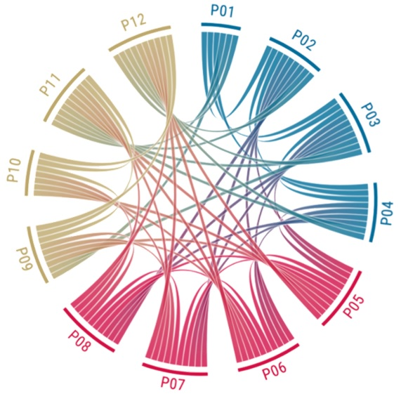

with the given data:

Quick look at the data

```
##      X P1 P2 P3 P4 P5 P6 P7 P8 P9 P10 P11 P12
## 1   P1  0 NA NA NA NA NA NA NA NA  NA  NA  NA
## 2   P2  1  0 NA NA NA NA NA NA NA  NA  NA  NA
## 3   P3  1  1  0 NA NA NA NA NA NA  NA  NA  NA
## 4   P4  1  1  1  0 NA NA NA NA NA  NA  NA  NA
## 5   P5  0  1  1  1  0 NA NA NA NA  NA  NA  NA
## 6   P6  0  1  1  1  1  0 NA NA NA  NA  NA  NA
## 7   P7  0  1  1  1  1  1  0 NA NA  NA  NA  NA
## 8   P8  0  1  1  1  1  1  1  0 NA  NA  NA  NA
## 9   P9  1  0  1  0  0  1  1  1  0  NA  NA  NA
## 10 P10  0  0  0  0  0  1  1  1  1   0  NA  NA
## 11 P11  1  1  1  1  1  1  1  1  1   1   0  NA
## 12 P12  1  1  1  1  1  1  1  1  1   1   0   0
```

Based on the format of the data, we need to find a function which takes a correlation matrix as input and plots it as a chord diagram.

We find such a function in the circlize package.

**for nerds:** quick look at the new data frame after formatting

```
## 'data.frame':    144 obs. of  3 variables:
##  $ A: chr  "P1" "P1" "P1" "P1" ...
##  $ B: chr  "P1" "P2" "P3" "P4" ...
##  $ C: num  0 0 0 0 0 0 0 0 0 0 ...
```

As you can see, since columns A and B contain 12x12 values, the connections from the beforehand 2D adjacency matrix can be encoded in the 1D column C. This can be then fed into the chordDiagram function of circlize.

### Final chord plot

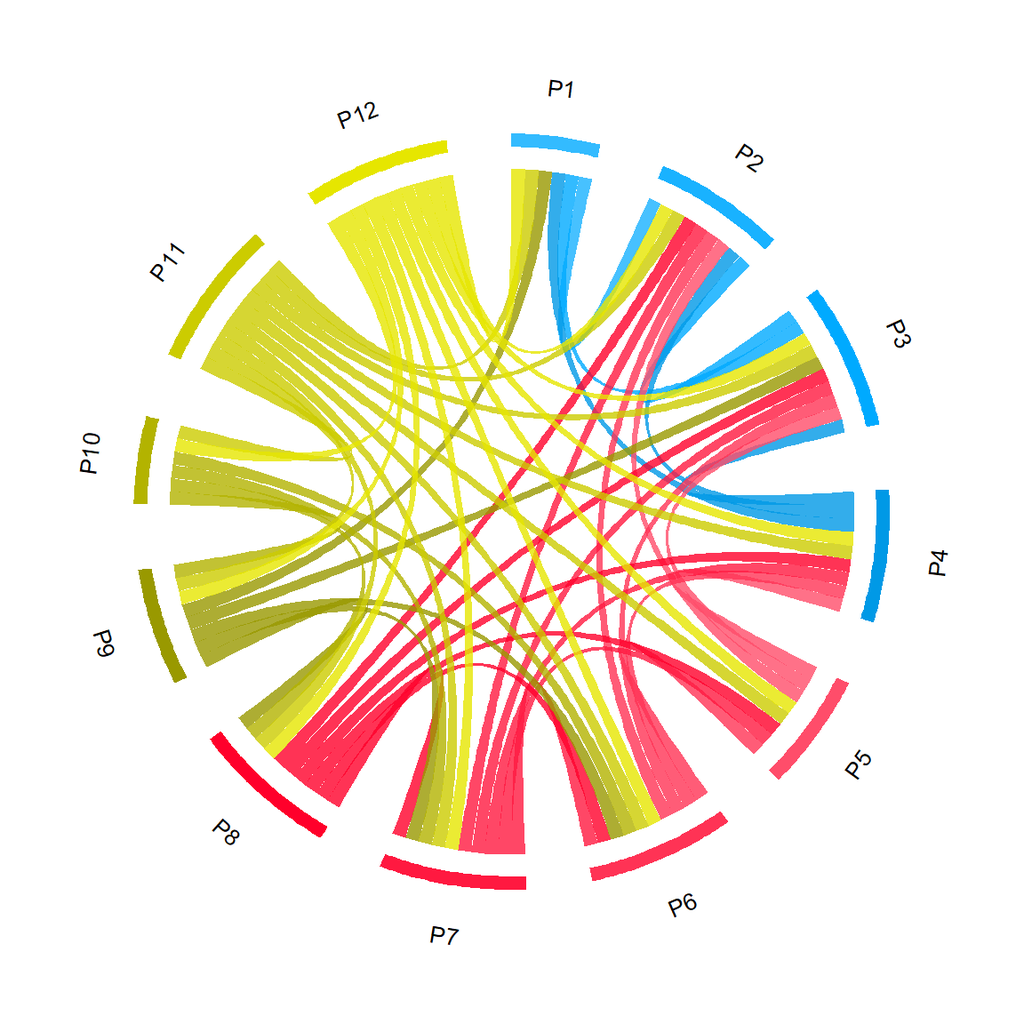

## Project 3: Analyzing and communicating findings from the RIJKS Museum data set

GOAL: Visualize the count of different artworks based on their medium over the years

### Dataset

```r
head(dat)
```

```
##                                            title          type       creator
## 1                              Ronde wierookdoos   wierookdoos     lacquerer
## 2 Schotel met een voorstelling van de kruisiging       schotel     anonymous
## 3                                  Zwaardmesheft        kozuka     anonymous
## 4                               Zwaardstootplaat         tsuba Shoami Ietake
## 5                               Zwaardstootplaat         tsuba     anonymous
## 6                      Fragment van een deurpost beeldhouwwerk     anonymous
##   year
## 1 1923
## 2 1780
## 3 1500
## 4 1600
## 5 1600
## 6  200
```

To be able to do a count of type by year, we will factorize year and aggregate over it

```
## # A tibble: 7 × 3
##   type                   numObjects EN_type
##   <chr>                       <int> <chr>
## 1 prent                        4921 Print
## 2 foto                         1499 Photograph
## 3 tekening                      665 Drawing
## 4 schetsboekblad                430 Sketchbook sheet
## 5 fotomechanische afdruk        401 Photomechanical print
## 6 ex libris                     193 Ex libris
## 7 stereofoto                    163 Stereo photograph
```

Notice how the top 7 art mediums (8272) represent the significant majority of art objects at the museum (total of 9986). Interesting.

### Ok, now finally the plot(s)

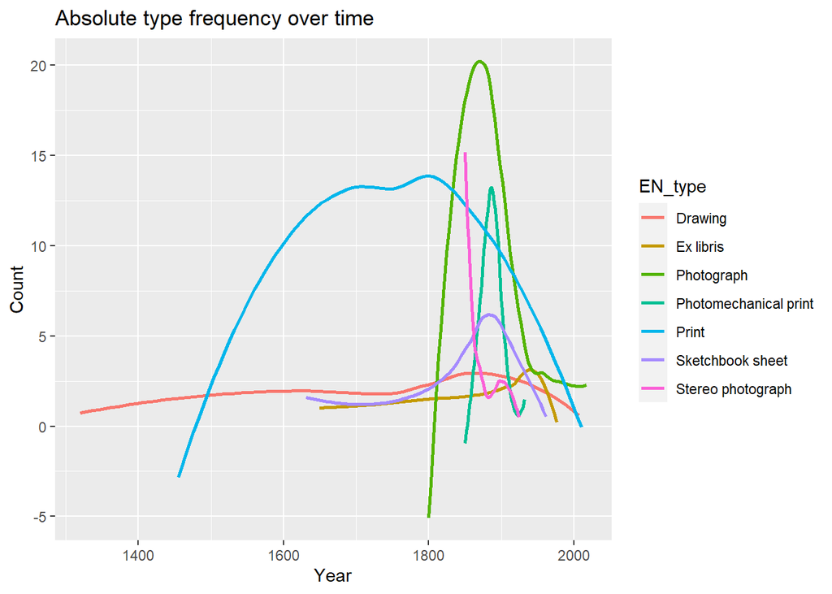

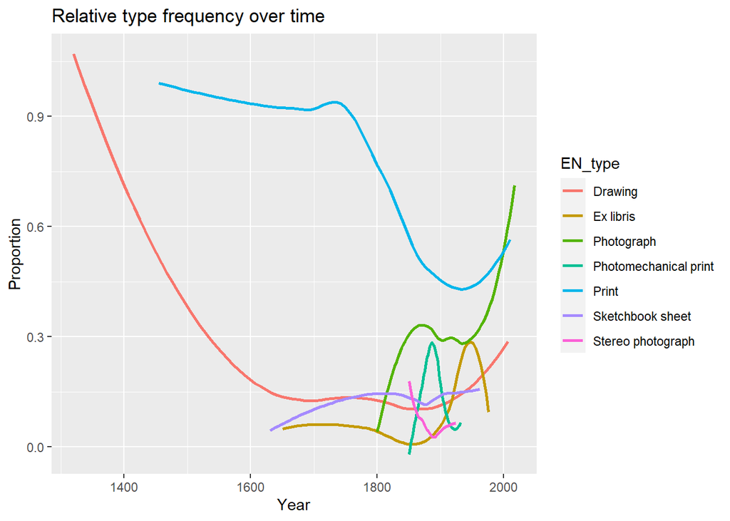

These two plots give us a better understanding about the art’s timeline at the museum. We can observe approximately when the first prints or photographs were developed, how some art forms had a shorter lived life (stereo photograph, photomechanical print) and how the classic drawing maintains its relevance from the start of history up to today.